# Machine Learning: Introduction

Updated April 24, 2020

## Introduction

## What is ML?

As with any concept, machine learning may have a slightly different definition, depending on whom you ask. A little compilation of definitions by academics and practioneers alike:

- “Machine Learning at its most basic is the practice of using algorithms to parse data, learn from it, and then make a determination or prediction about something in the world.” - Nvidia
- “Machine learning is the science of getting computers to act without being explicitly programmed.” - Stanford
- “Machine learning is based on algorithms that can learn from data without relying on rules-based programming.”- McKinsey & Co.
- “Machine learning algorithms can figure out how to perform important tasks by generalizing from examples.” - University of Washington
- “The field of Machine Learning seeks to answer the question”How can we build computer systems that automatically improve with experience, and what are the fundamental laws that govern all learning processes?" - Carnegie Mellon University

## Supervised vs. Unsupervised ML

### Unsupervised ML

Tasks related to pattern recognition and data exploration, in dase there yet does not exist a right answer or problem structure. Main application

1. **Dimensionality reduction:** Finding patterns in the features of the data
2. **Clustering:** Finding homogenous subgroups within larger group

### Supervised ML

- Concerned with labeling/classification/input-output-mapping/prediction tasks
- Subject of the next lecture, so stay patient

This is what is currently driving >90% ML applications in research, industry, and policy, and will be the focus on the following sessions.

## Supervised vs. Unsupervised ML

### An intuitive perspective

[figure not shown]

### A functional perspective

[figure not shown]

## Contrasting ML with inferential statistics

## Inferential Statistics

- Mostly interested in producing good **parameter estimates**: Construct models with unbiased estimates of \(\beta\), capturing the relationship \(x\) and \(y\).
- Supposedly models: Causal effect of directionality \(x \rightarrow y\), robust across a variety of observed as well as up to now unobserved settings.
- How: Carefully draw from theories and empirical findings, apply logical reasoning to formulate hypotheses.
- Typically, multivariate testing, cetris paribus.
- Main concern: Minimize standard errors \(\epsilon\) of \(\beta\) estimates.
- Not overly concerned with overall predictive power (eg. \(R^2\)) of those models, but about various type of endogeneity issues, leading us to develop sophisticated **identification strategies**

## ML Approach

- To large extend driven by the needs of the private sector \(\rightarrow\) data analysis is gear towards producing good **predictions** of outcomes \(\rightarrow\) fits for \(\hat{y}\), not \(\hat{\beta}\)
  - Recommender systems: Amazon, Netflix, Sportify ect.
  - Risk scores}: Eg.g likelihood that a particular person has an accident, turns sick, or defaults on their credit.
  - Image classification: Finding Cats & Dogs online
  - Predictive policing
- Often rely on big data (N,\(x_i\))
- Not overly concerned with the properties of parameter estimates, but very rigorous in optimizing the overall prediction accuracy.
- Often more flexibility wrt. the functional form, and non-parametric approaches.
- No “build-in”" causality guarantee \(\rightarrow\) verification techniques.
- Often sporadically used in econometric procedures, but seen as “son of a lesser god”.

## Statistics Refresher

## Introduction to regression problems

Lets for a second recap linear regression techniques, foremost the common allrounder and workhorse of statistical research since some 100 years.

### OLS Basic Properties

- Outcome: contionous
- Predictors: continous, dichotonomous, categorical
- When to use: Predicting a phenomenon that scales and can be measured continuously

### Functional form

\[y = \beta_0 + \beta_1 x_1 + \beta_2 x_2 + ... + \beta_n x_n + \epsilon \]

where:

- \(y\) = Outcome, \(x_i\) = observed value \(ID_i\)
- \(\beta_0\) = Constant
- \(\beta_i\) = Estimated effect of \(x_i\) on \(y\) , slope of the linear function
- \(\epsilon\) = Error term

And that is what happens. Lets imagine we plot some feature against an outcome we want to predict. OLS will just fit a straight line through your data.

[figure not shown]

We do so by minimizing the sum of (squared) errors between our prediction-line and the observed outcome.

[figure not shown]

## Regression Example

Let’ do a brief example for a simple linear model. We generate some data, where \(y\) is a linear function of \(x\) plus some random error.

```r
data <- tibble(x = runif(500, min = 0, max = 100),
               y = 15 + (x*0.3) + rnorm(500, sd = 5))
```

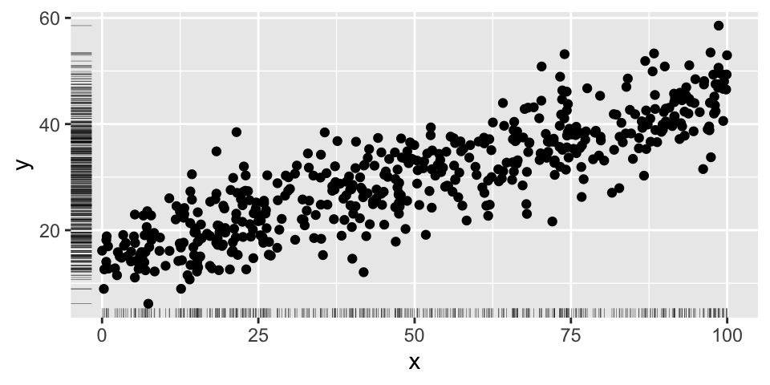

We can now fit a linear regression model that aims at discovering the underlying relationship.

```r
fit_lm <- data %>% glm(formula = y ~ x, family = gaussian)
fit_lm %>% summary()
```

```
##
## Call:
## glm(formula = y ~ x, family = gaussian, data = .)
##
## Deviance Residuals:
##     Min       1Q   Median       3Q      Max
## -15.423   -3.317   -0.170    3.337   17.157
##
## Coefficients:
##              Estimate Std. Error t value Pr(>|t|)
## (Intercept) 14.791865   0.452922   32.66   <2e-16 ***
## x            0.303863   0.007865   38.63   <2e-16 ***
## ---
## Signif. codes:  0 '***' 0.001 '**' 0.01 '*' 0.05 '.' 0.1 ' ' 1
##
## (Dispersion parameter for gaussian family taken to be 26.24439)
##
##     Null deviance: 52244  on 499  degrees of freedom
## Residual deviance: 13070  on 498  degrees of freedom
## AIC: 3056.7
##
## Number of Fisher Scoring iterations: 2
```

- We can also visualize that
- We see the model puts a straight line through our data
- This line tells us how to predict the outcome `y` based on observed values of `x`
- The coeffficient indicates the slope of this linear function.

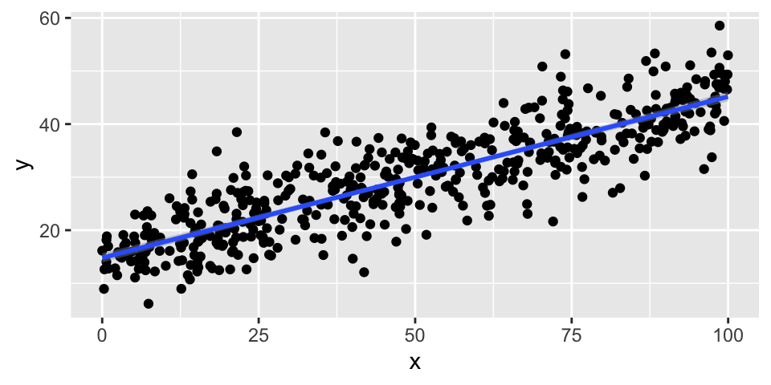

## Prediction based on fitted model

- After the model’s parameters are fitted, we can use it to pedict our outcome of interest.
- Is here done on the same data, but obviously in most cases more elevant on new data.

```r
pred_lm <- fit_lm %>% predict()
pred_lm %>% head()
```

```
##        1        2        3        4        5        6
## 32.30412 31.95226 17.04015 28.58314 26.13442 24.85936
```

## Assesing predictive power of the model

- So, how well does our model now predict?
- A common measure of predictive power of regressions models is the *Root-Mean-Squared-Error* (RSME), calculate as follows:

\[ RMSE = \sqrt{\frac{1}{n}\Sigma_{i=1}^{n}{\Big(y_i - \hat{y_i} \Big)^2}}\]

Keep in mind, this root&squared thingy does nothing with the error term except of transforming negative to positive values. Lets calculate:

```r
error <-  pull(data, y) -  pred_lm

# Calculate RMSE
sqrt(mean(error ^ 2))
```

```
## [1] 5.112672
```

```r
# (error ^ 2) %>% mean() %>% sqrt()
```